# How to calculate biodiversity effects across space and time (sensu Isbell et al. 2018, Ecology Letters)

### Introduction

The field of biodiversity-ecosystem functioning (BEF) studies the relationship between biological diversity and different ecosystem processes or functions (primary productivity, nutrient cycling etc.), (reviewed in Cardinale *et al.* 2012). One of the key tools in the BEF researcher’s toolbox is the partition proposed by Loreau and Hector (2001, *Nature*). This partition allows researchers to decompose a net biodiversity effect (i.e. the difference in mixture functioning relative to the expected functioning based only on monoculture yields and initial relative proportions or, relative expected yields, RYe) into two effects:

- 1. The complementarity effect which describes processes related to facilitation and niche partitioning between species. This allows all species, on average, to perform better in mixture than expected based on their functioning in monoculture.
- 2. The selection effect which describes the effect of biodiversity that comes from high functioning, dominant species being more likely to be present in a given community.

This partition has been very useful in the BEF field for helping to identify mechanisms driving biodiversity effects. However, this method generally only looks at the effect of biodiversity in single patches. It does not account for biodiversity effects that can arise at larger scales of space and time. For example, a single species may dominate a patch (i.e. strong selection effect) but if different species dominate different patches, we can get a complementarity effect arising at larger spatial scales.

### Isbell et al.’s (2018, *Ecology Letters*) extension

TS is then further partitioned into two different effects

- 1. Non-random overyielding (NO)
- 2. Total insurance (IT)

Finally, IT is then partitioned into four different effects

- 1. Average selection (AS)
- 2. Spatial insurance (SI)
- 3. Temporal insurance (TI)
- 4. Spatio-temporal insurance (ST

For descriptions of these different effects, see Isbell et al. (2018, *Ecology Letters*) or Hagan et al. (in prep.).

Currently, *general code* for calculating these effects has not been developed (Isbell et al. 2018 included code for calculating these effects in specific cases). Therefore, we provide a script that contains a function that can calculate these effects for any number of species across any number of times and places:

- 01_isbell_2018_partition.R

In addition, the script includes an extension proposed by Hagan et al. (in prep.) to incorporate uncertainty in expected relative yields (RYe) using samples from a Dirichlet distribution. This is a tutorial that explains how to use this script.

Currently, the script is hosted on Github: https://github.com/haganjam/BEF_quant_scale/blob/main/scripts/01_partition_functions/01_isbell_2018_partition.R

### How to use the functions?

The script contains several functions that need to be loaded. This can be done by simply downloading the script and running the functions so that they are loaded into the R environment. Otherwise, if the script is saved in the working directory, one can use the *source() function* to call the functions from a clean script, e.g.:

```r
# source("working_directory/01_isbell_2018_partition.R)
source("C:/Users/james/Documents/github/BEF_quant_scale/scripts/01_partition_functions/01_isbell_2018_partition.R")
```

The main function used to calculate the biodiversity effects is:

```r
# Isbell_2018_sampler(data, RYe_post = FALSE, N = 100, RYe, alpha_par = 4)
```

- 1. sample - unique sample id for each place x time combination
- 2. place - place from which data were collected (i.e. a code)
- 3. time - time at which data were collected (i.e. a code)
- 4. species - species name or code
- 5. M - monoculture yield of the species at the specific time x place combination
- 6. Y - mixture yield of the species at the specific time x place combination

Importantly, the time variable is simply a different time not an actual date. Therefore, a typical time-variable might be 1, 2 and 3 representing three different time points. In addition, all species’ names need to be present at all times and places in the data even if their monoculture or mixture functioning is zero.

Here is an example of a dataset that would be accepted by isbell_2018_sampler() which comes from Table 2 in Isbell et al. (2018, *Ecology Letters*).

```r
df_template <-

  data.frame(sample = rep(c(1:4), each = 2),
             time = c(1,1,1,1,2,2,2,2),
             place = c(1,1,2,2,1,1,2,2),
             species = c(1,2,1,2,1,2,1,2),
             M = c(100,50,50,100,100,50,50,100),
             Y = c(100,0,0,100,100,0,0,100))

print(df_template)
```

```
##   sample time place species   M   Y
## 1      1    1     1       1 100 100
## 2      1    1     1       2  50   0
## 3      2    1     2       1  50   0
## 4      2    1     2       2 100 100
## 5      3    2     1       1 100 100
## 6      3    2     1       2  50   0
## 7      4    2     2       1  50   0
## 8      4    2     2       2 100 100
```

The next argument, **RYe_post**, is a *TRUE* or *FALSE* argument. If *TRUE*, the function will calculate a distribution of each biodiversity effect where each different value assumes a different set of RYe values from a Dirichlet distribution. The number of samples to draw from the Dirichlet distribution is given by the **N** argument and the argument **alpha_par** is the alpha parameter in the Dirichlet distribution which determines the skewness of the distribution. An example of a set of 100 samples from the Dirichlet distribution with an alpha value of four for three species is given below. Each line is one sample and the numbers sum to one.

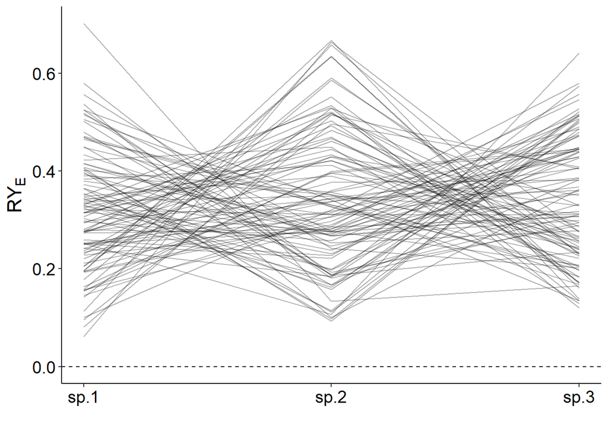

```r
# load the relevant packages
require(ggplot2)
require(gtools)
require(tidyr)
require(dplyr)

# draw samples from the Dirichlet distribution
species <- 3
p1 <-
  lapply(1:100, function(x) {

  x <- gtools::rdirichlet(n = 1, rep(4,  species) )
  x.df <- as.data.frame(x)
  names(x.df) <- paste0("sp.", 1:species)
  return(x.df)

  } ) %>%
  bind_rows(., .id = "id") %>%
  pivot_longer(cols = c("sp.1", "sp.2", "sp.3"),
               names_to = "species",
               values_to = "RYe") %>%
  ggplot(data = .,
         mapping = aes(x = species, y = RYe, group = id)) +
  geom_line(alpha = 0.3) +
  geom_hline(yintercept = 0, linetype = "dashed", colour = "black") +
  scale_x_discrete(expand = c(0.03, 0.03)) +
  ylab(expression(RY[E])) +
  xlab("") +
  theme_classic() +
  theme(axis.text = element_text(colour = "black", size = 14),
        axis.title = element_text(size = 16))

plot(p1)
```

This can be useful because, often, we don’t know the expected relative yields. This method allows us to still calculate the biodiversity effects whilst incorporating uncertainty in the RYe values.

If **RYe_post** = *FALSE*, then we need to provide RYe values directly into the **RYe** argument. For each species, we need one of these values and, overall, the values must sum to one.

Now that we know how to use the *isbell_2018_sampler()* function, we will use it to calculate the biodiversity effects on some example data assuming known and unknown RYe values.

First, we define a dataset (Isbell et al. 2018, Table 2) with two species at two times and two places.

```r
df.test1 <-
  data.frame(sample = rep(c(1:4), each = 2),
                  time=c(1,1,1,1,2,2,2,2),
                  place=c(1,1,2,2,1,1,2,2),
                  species=c(1,2,1,2,1,2,1,2),
                  M=c(100,50,100,50,50,100,50,100),
                  Y=c(100,0,100,0,0,100,0,100))
```

To start with, we assume equal RYe values for the two species (i.e. 0.5 and 0.5) and we use the isbell_2018_sampler() function to calculate the biodiversity effects. We add df_test1 to the **data** argument and c(0.5, 0.5) to the **RYe** argument because we set **RYe_post** = FALSE because we know the RYe values.

```r
df.test1.out <- Isbell_2018_sampler(data = df.test1,
                                    RYe_post = FALSE,
                                    RYe = c(0.5, 0.5))
```

Let’s view the output of the function. First, we can view the effects proposed by Isbell et al. (2018, *Ecology Letters*).

```r
print(df.test1.out$Beff)
```

```
##   Beff Value
## 1  NBE   100
## 2   TC     0
## 3   TS   100
## 4   NO     0
## 5   IT   100
## 6   AS     0
## 7   TI   100
## 8   SI     0
## 9   ST     0
```

In this example data, the net biodiversity effect is 100 and it is completely explained by temporal insurance effects. The reason for this is that two different species dominate at the times where they are highest functioning in monoculture.

Second, we view the sum of local complementarity and local selection effects as calculated per Loreau and Hector (2001):

```r
print(df.test1.out$L.Beff)
```

```
##   L.Beff Value
## 1     LC     0
## 2     LS   100
```

Next, we assume that we don’t know the RYe. Therefore, instead of a single biodiversity effect, we will get a distribution of each effect. Here, we set **RYe_post** as TRUE, **N** = 100 and **alpha_par** as 4.

```r
# create a test dataset
df.test2 <-
  expand.grid(sample = rep(1:4, each = 3),
              species = c(1, 2, 3),
              place = c(1, 2),
              time = c(1, 2, 3))

# rearrange the columns
df.test2 <- df.test2[, c(4, 3, 2, 1)]

# add monoculture and mixture values
df.test2$M <- round(rnorm(n = nrow(df.test2), 100, 10), 0)
df.test2$Y <- round(rnorm(n = nrow(df.test2), 80, 10), 0)

df.test2.out <- Isbell_2018_sampler(data = df.test2,
                                    RYe_post = TRUE,
                                    N = 100,
                                    alpha_par = 4)
print(head(df.test2.out) )
```

```
##   sample Beff         Value
## 1      1  NBE  1.005921e+04
## 2      1   TC  8.578423e+02
## 3      1   TS -1.957462e+01
## 4      1   NO -1.894600e+01
## 5      1   IT -7.543505e+00
## 6      1   AS  4.213838e-03
```

The output we get now is a data.frame with a column for sample. This column corresponds to a sample from the Dirichlet distribution. Now, instead of simply viewing the data in a table, we can plot it as a histogram.

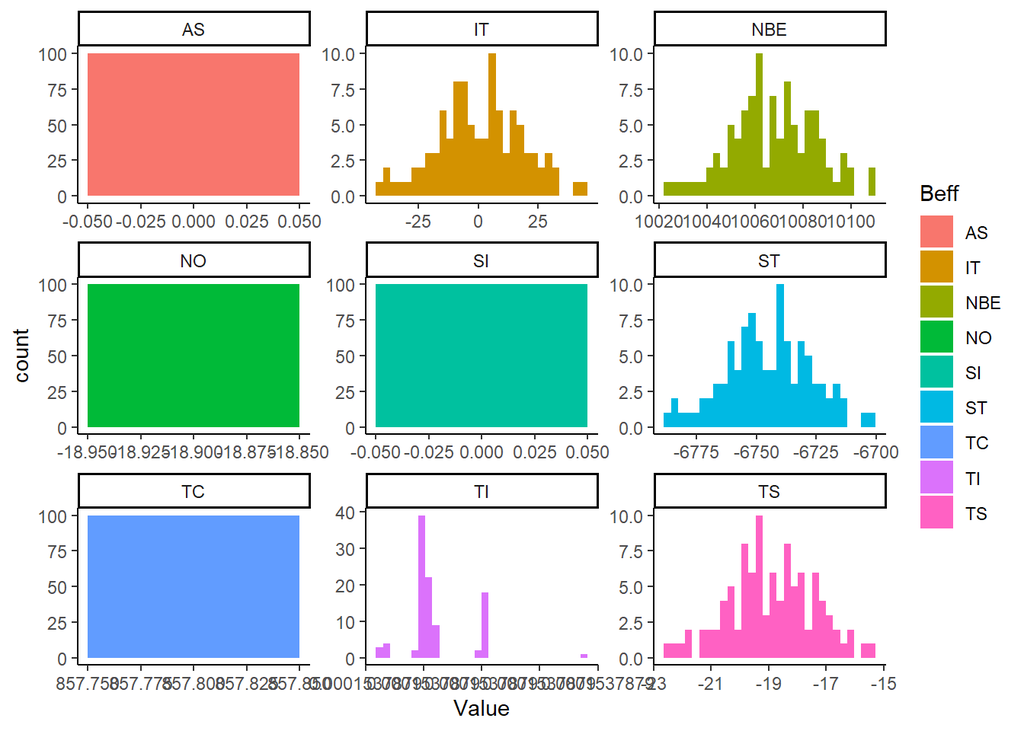

```r
require(ggplot2)

ggplot(data = df.test2.out,
       mapping = aes(x = Value, fill = Beff)) +
  geom_histogram() +
  facet_wrap(~Beff, scales = "free") +
  theme_classic()
```

Hopefully, this tutorial is useful to anyone looking to implement Isbell et al.’s (2018) partition of biodiversity effects.

**References**

Isbell *et al.* (2018, *Ecology Letters*): Quantifying effects of biodiversity on ecosystem functioning across times and places.

Hagan *et al.* (in prep.): Quantifying the effects of biodiversity on ecosystem functioning across space and time in natural and semi-natural ecosystems.